# primary_data

Jose Rico

8/14/2019

## Importing Data

FiveThirtyEight’s Polls Project https://projects.fivethirtyeight.com/polls/ provides access to the most recent polls at https://github.com/fivethirtyeight/data. They provide a **url** for direct access the data in **csv** format

```r
primary <- read.csv("https://projects.fivethirtyeight.com/polls-page/president_primary_polls.csv")
primary_t <- tibble(primary)
```

## Examine Structure of Data

If you want to quickly see data, just enter the data set’s name, `primary` or click on it in the **Environment** tab

Sometimes the original data frame in too large, you can use the `select()` command from **tidyverse**  
Note: ‘Select’ is for the columns of the data frame (aka the variables).

```r
primary_a <- primary %>%
     select(poll_id, state, pollster, fte_grade, sample_size, population, population_full, methodology, end_date, nationwide_batch, answer, pct)
```

```r
primary_a1 <- primary_a %>%
  rename(candidate_name=answer)
```

work on candidate_name data type (maybe that’s the problem?)

Filter out top candidates (using code from R4DS not moderndive)

```r
primary_a2 <- filter(primary_a1, candidate_name %in% c("Biden", "Gabbard", "Booker", "Castro", "Sanders", "Gillibrand", "Harris", "O'Rourke", "Buttigieg", "Warren", "Kolbuchar", "Yang", "Steyer"))
```

Filter out based on fte_grade A, A-, B+, B, B- keep

```r
primary_a3 <- filter(primary_a2, fte_grade %in% c("A", "A-", "B+", "B", "B-"))
```

Filter out just polls conducted either strictly **live phone** or **online**

```r
primary_a4 <- filter(primary_a3, methodology %in% c("Live Phone", "Online"))
```

View timeline of just a couple candidate polling at a time.

```r
primary_a5 <-filter(primary_a4, candidate_name %in% c("Sanders", "Biden" , "Harris", "Warren", "O'Rourke", "Buttigieg"))
```

Filter since just before the first debate

```r
primary_a6 <-filter(primary_a5, poll_id > 58488)
```

View the each candidate’s percentage data from all polls in a visual summary know boxplot. Choose 2 or 3 (2 is all polls, 3 is only A and B fte_rated polls)

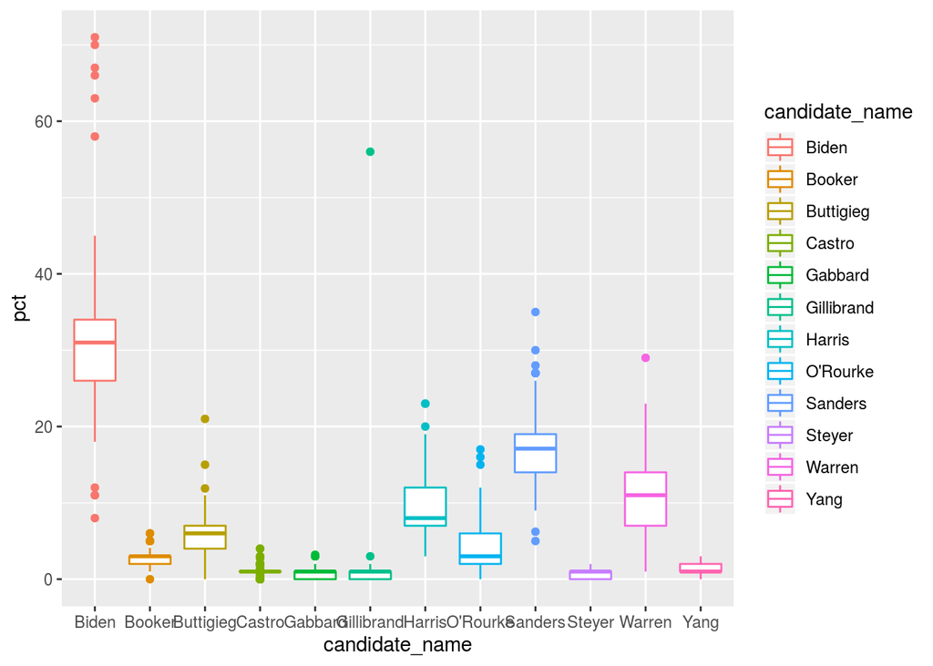

```r
ggplot(data=primary_a4, mapping = aes(x=candidate_name, y=pct, color=candidate_name))+
     geom_boxplot()
```

Try to get the 2 on the same output

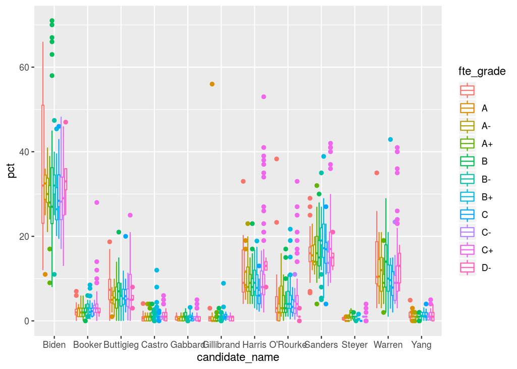

```r
ggplot(data=primary_a2, mapping = aes(x=candidate_name, y=pct, color=fte_grade))+
     geom_boxplot()
```

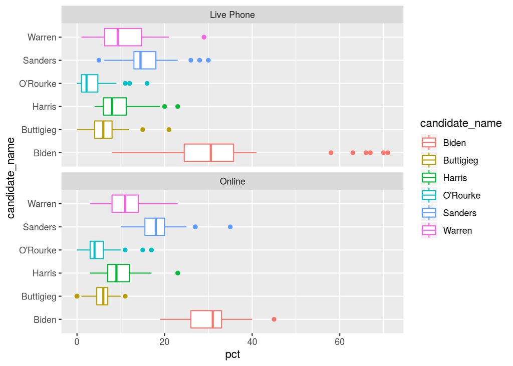

```r
ggplot(data=primary_a5, mapping = aes(x=candidate_name, y=pct, color=candidate_name))+
    geom_boxplot()+
    coord_flip()+
    facet_wrap(~ methodology, nrow=2 )
```

Trendlines data from before first debate to know

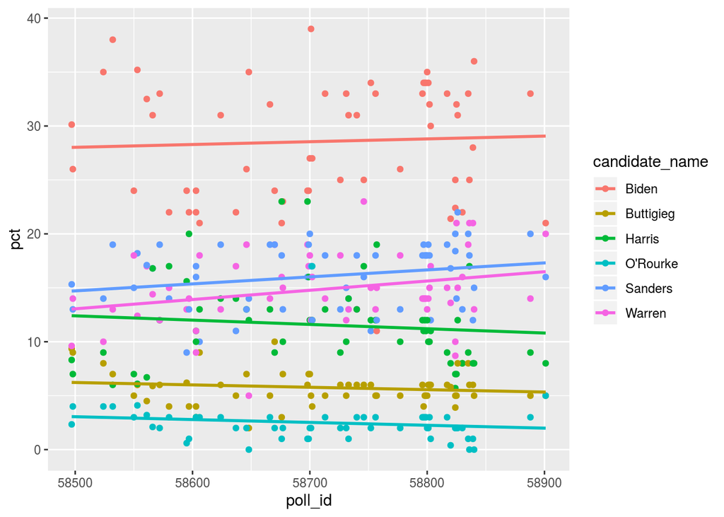

```r
ggplot(data=primary_a6, mapping = aes(x=poll_id, y=pct, color=candidate_name ))+
    geom_point()+
    geom_smooth(method="lm", se = FALSE)
```

Prefer to use dates on x axis need to convert dates to days to election first convert data format to `date`

```r
primary_a7 <- primary_a6 %>%
  mutate(en_date1 = as.Date.factor(end_date, format = "%m/%d/%Y"))
```

next create new variable days_to_NH need **lubridate** package (still working on this)

```r
NH_primary <- "2/11/19"
NH_primary <- as.Date.factor(NH_primary, format = "%m/%d/%Y")
#primary_a8 <- primary_a7 %>%
#  mutate(days_to_NH = ddays(NH_primary -en_date1 ))
```

Summary Data on Each Candidate

Histograms of each candidate poll numbers

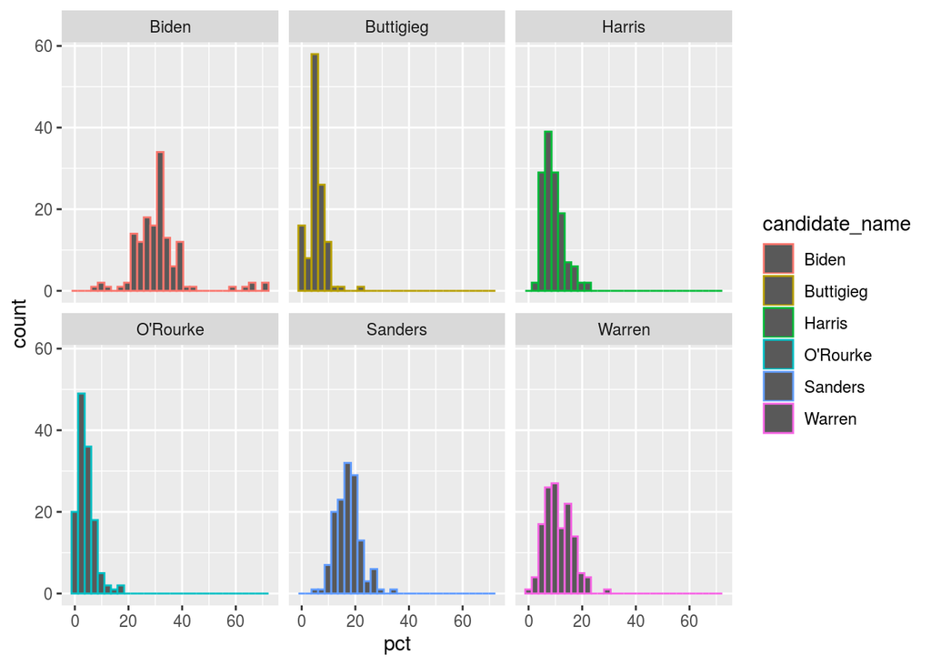

```r
ggplot(data=primary_a5, mapping = aes(pct, color=candidate_name, size = sample_size ))+
    geom_histogram() +
    facet_wrap(~ candidate_name)
```

Select polls ending after June 18

```r
primary_a6 <-filter(primary_a5, poll_id > 58488)
```